# Covid-19 Analysis-USA

#### 3.Now let us look at the daily changes, we can compute this using growth.rate() function.

*The growth rate is defined as the ratio of the daily changes between two consecutive dates.*

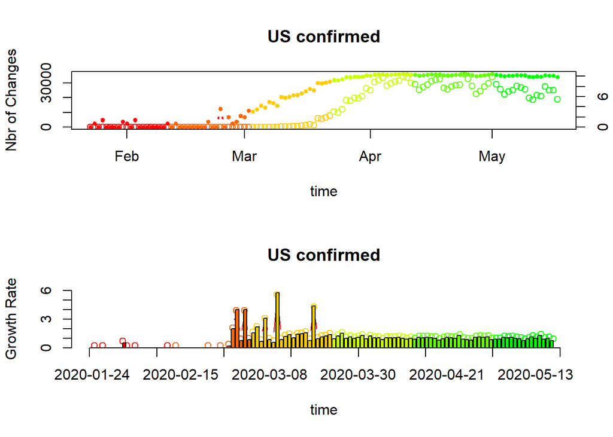

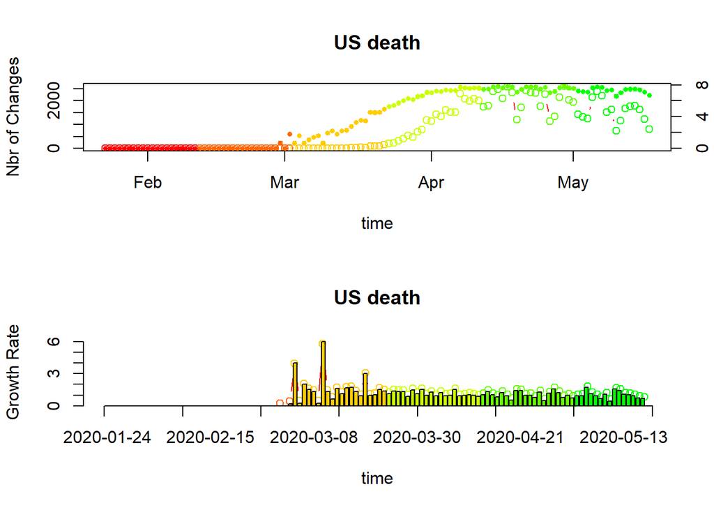

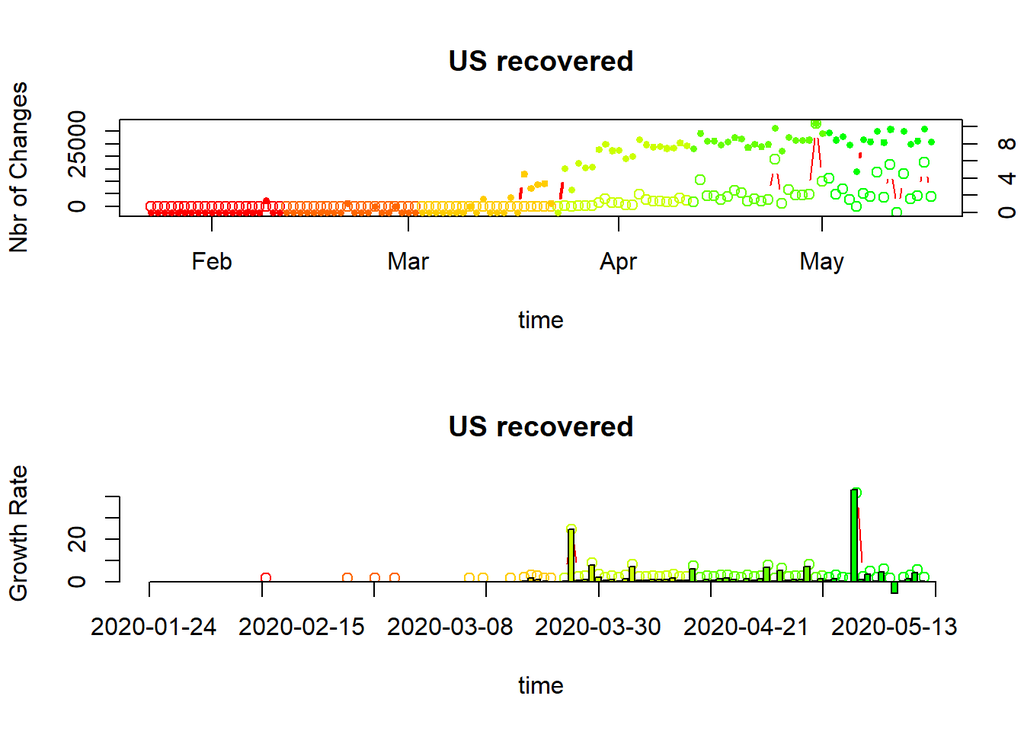

```r
# read time series data for confirmed cases
data <- covid19.data("ts-ALL")
growth.rate(data, geo.loc = "US")
```

- From the above scatter and bar plots, we can see as the number of confirmed cases are increasing rapidly, recovered cases are increasing too which means people are getting cured faster. Less number of deaths has been observed as compared to the number of confirmed and recovered cases i.e. out of 1.4 million confirmed cases, 6% of people lead to death.